# Reproducing Hicks et al. results: Leng data

Joyce Hsiao

2016-02-16

## Background and objectives

Reproduce findings presented in Hicks et al. using [Leng2015](https://dx.doi.org/10.1038/nmeth.3549) read counts.

Note that the PC component scores in Hicks et al. were computed without using unit variance. PC scores computed on unit variances can be different from scores computed on raw variances. We keep our computations here consistent with the method used in Hicks et al.

## Setup

```r
library("edgeR")
require(matrixStats)
library("gmodels")
require(GenomicRanges)
```

## Pseudocount - edgeR

We compare two methods of adding pseudocount:

1. log2(1e6*count/depth + prior.count): Used in Hicks et al., 2016. `prior.count = 1`. `depth` denotes total count in the sample.
2. log2( 1e*6(count + prior.count.scaled)/depth.scaled ): Used in edgeR normalization. `prior.count.scaled = lib.size/mean(lib.size)*prior.count` where `prior.count = .25`. `depth.scaled` denotes `lib.size + 2*prior.count.scaled`.

## Import data

```r
leng2015 <- readRDS("../data/all-rds/leng2015.rds")

# access count matrix
counts <- assays(leng2015)$counts
dim(counts)
```

```
## [1] 19084   460
```

```r
summary(counts[ , 1:3])
```

```
##   H1_Exp1.001        H1_Exp1.002        H1_Exp1.003
##  Min.   :    0.00   Min.   :    0.00   Min.   :    0.00
##  1st Qu.:    0.00   1st Qu.:    0.00   1st Qu.:    0.00
##  Median :    2.41   Median :    1.96   Median :    2.82
##  Mean   :  173.03   Mean   :  179.92   Mean   :  176.70
##  3rd Qu.:  101.42   3rd Qu.:  102.23   3rd Qu.:  101.55
##  Max.   :46539.56   Max.   :48209.27   Max.   :56022.53
```

log2 CPM of leng counts

```r
leng_log2cpm <- log2( 1e6 * sweep(counts, 2,
                                   STATS = colSums(counts),
                                   FUN = "/") + 1)
dim(leng_log2cpm)
```

```
## [1] 19084   460
```

Proportion of genes detected.

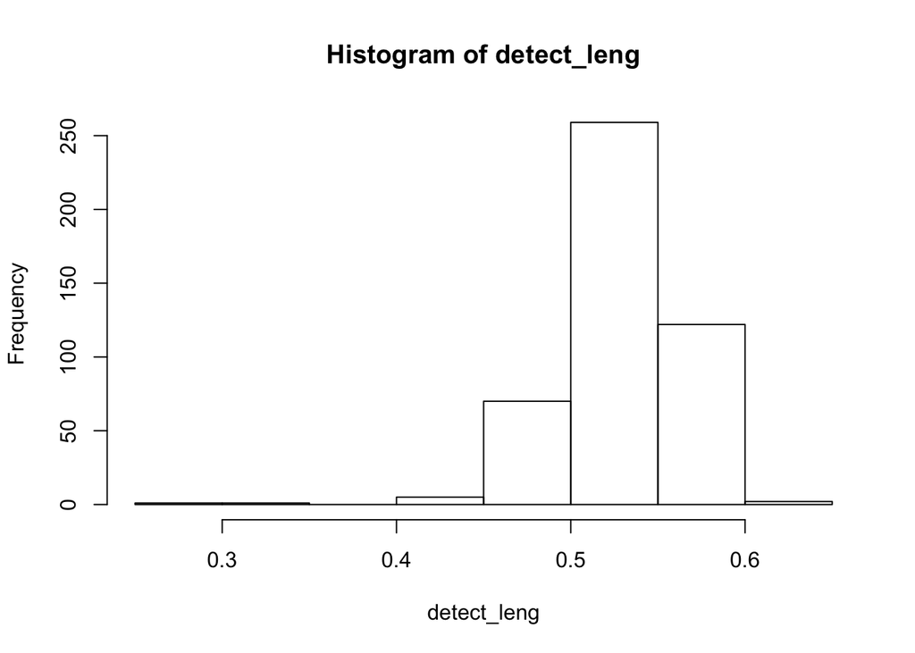

```r
detect_leng <- colMeans( counts != 0)
hist(detect_leng)
```

We noted that in Hicks et al., 458 cells were reported in the analysis. 2 cells with less than 40% of genes detected were excluded from the analysis.

```r
sum(detect_leng < .40)
```

```
## [1] 2
```

```r
leng_log2cpm_filter <- leng_log2cpm[ , (detect_leng > .40)]
which_detect_include <- which(detect_leng > .40)

dim(leng_log2cpm_filter)
```

```
## [1] 19084   458
```

edgeR pseudocount

```r
leng_log2cpm_edger <- edgeR::cpm( counts[ ,which_detect_include],
                                  log = TRUE)
```

Define a set of ubiquitous genes that are mapped in every cell.

```r
which_ubiquitous <- which(rowSums(counts > 0) == NCOL(counts))
```

## PCA

No scaling

```r
if (file.exists("../rdas/pca-correlation-other-umi-leng/pca_leng.rda")) {
    load("../rdas/pca-correlation-other-umi-leng/pca_leng.rda")
} else {
    svd_leng <- gmodels::fast.svd( scale(t(leng_log2cpm_filter), scale = FALSE) )
    svd_leng_edger <- gmodels::fast.svd( scale(t(leng_log2cpm_edger), scale = FALSE) )

    svd_leng_ubiq <-
        gmodels::fast.svd( scale(t(leng_log2cpm_filter[which_ubiquitous, ]),
                                 scale = FALSE) )
    svd_leng_edger_ubiq <-
        gmodels::fast.svd( scale(t(leng_log2cpm_edger[which_ubiquitous, ]),
                                               scale = FALSE) )
    save(svd_leng, svd_leng_edger,
         svd_leng_ubiq, svd_leng_edger_ubiq,
         file = "../rdas/pca-correlation-other-umi-leng/pca_leng.rda")
}
```

Scaling. In order to use the scaling option, we need to exclude genes that do not have any mapped reads.

```r
which_gene_include <- which(rowSums(leng_log2cpm_filter > 0) > 0)
if (file.exists("../rdas/pca-correlation-other-umi-leng/pca_leng_scale.rda")) {
    load("../rdas/pca-correlation-other-umi-leng/pca_leng_scale.rda")
} else {
    svd_leng_scale <- gmodels::fast.svd(
        scale(t(leng_log2cpm_filter[which_gene_include, ]),
              scale = TRUE) )
    svd_leng_edger_scale <- gmodels::fast.svd(
        scale(t(leng_log2cpm_edger[which_gene_include, ]),
              scale = TRUE) )
    save(svd_leng, svd_leng_edger,
         svd_leng_ubiq, svd_leng_edger_ubiq,
         file = "../rdas/pca-correlation-other-umi-leng/pca_leng.rda")
}
```

## Proportion of genes detected

All genes

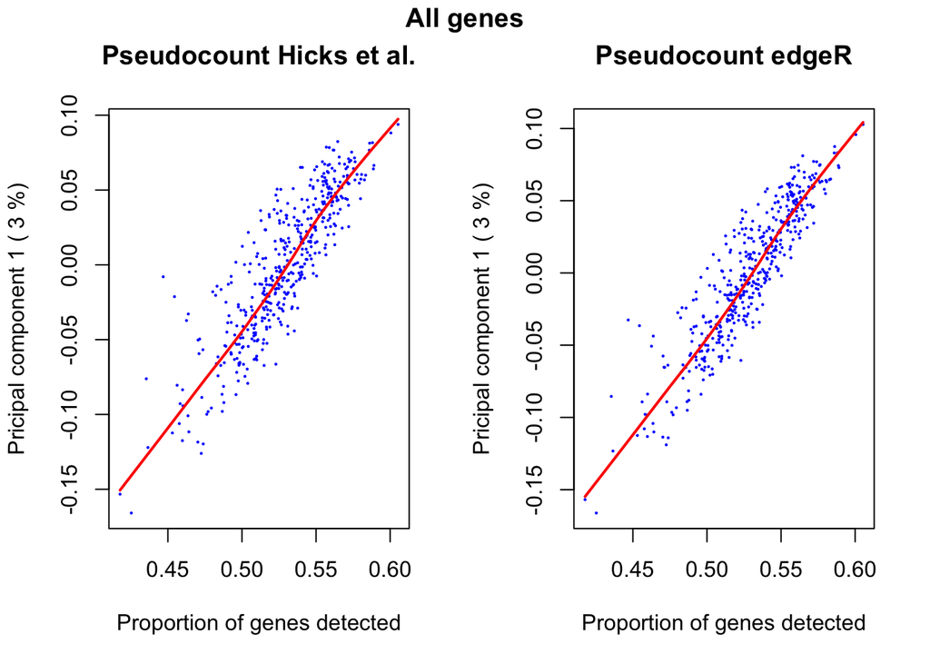

```r
par(mfrow = c(1,2))
pc_proportions_svd <- (svd_leng$d^2)/sum(svd_leng$d^2)
plot(x = detect_leng[which_detect_include],
     y = -1*svd_leng$u[, 1],
     xlab = "Proportion of genes detected",
     ylab = paste("Pricipal component 1 (",
                  100*round(pc_proportions_svd[1], 2),"%)"),
     pch = 16, cex = .3, col = "blue",
     main = "Pseudocount Hicks et al.")
lines(lowess(x = detect_leng[which_detect_include],
            y = -1*svd_leng$u[, 1]),
      col = "red", lwd = 2)

pc_proportions_svd_edger <- (svd_leng_edger$d^2)/sum(svd_leng_edger$d^2)
plot(x = detect_leng[which_detect_include],
     y = -1*svd_leng_edger$u[, 1],
     xlab = "Proportion of genes detected",
     ylab = paste("Pricipal component 1 (",
                  100*round(pc_proportions_svd_edger[1], 2),"%)"),
     pch = 16, cex = .3, col = "blue",
     main = "Pseudocount edgeR")
lines(lowess(x = detect_leng[which_detect_include],
            y = -1*svd_leng_edger$u[, 1]),
      col = "red", lwd = 2)

title(main = "All genes", outer = TRUE, line = -1)
```

Ubiquitous genes

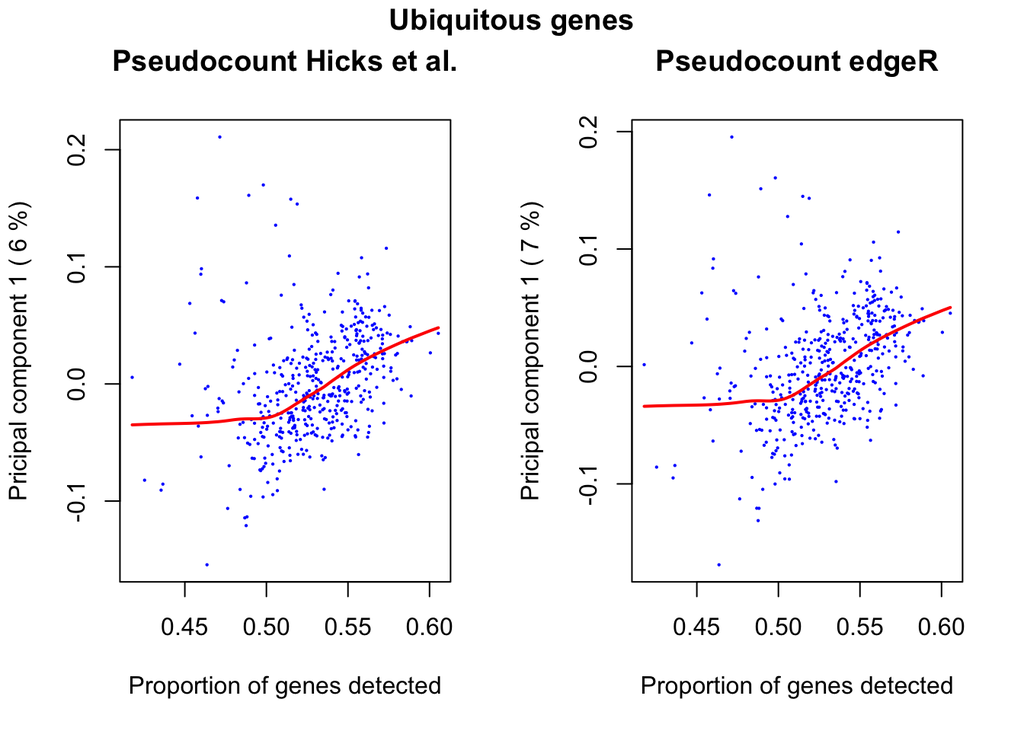

```r
par(mfrow = c(1,2))
pc_proportions_svd_ubiq <- (svd_leng_ubiq$d^2)/sum(svd_leng_ubiq$d^2)
plot(x = detect_leng[which_detect_include],
     y = -1*svd_leng_ubiq$u[, 1],
     xlab = "Proportion of genes detected",
     ylab = paste("Pricipal component 1 (",
                  100*round(pc_proportions_svd_ubiq[1], 2),"%)"),
     pch = 16, cex = .3, col = "blue",
     main = "Pseudocount Hicks et al.")
lines(lowess(x = detect_leng[which_detect_include],
            y = -1*svd_leng_ubiq$u[, 1]),
      col = "red", lwd = 2)


pc_proportions_svd_edger_ubiq <- (svd_leng_edger_ubiq$d^2)/sum(svd_leng_edger_ubiq$d^2)
plot(x = detect_leng[which_detect_include],
     y = -1*svd_leng_edger_ubiq$u[, 1],
     xlab = "Proportion of genes detected",
     ylab = paste("Pricipal component 1 (",
                  100*round(pc_proportions_svd_edger_ubiq[1], 2),"%)"),
     pch = 16, cex = .3, col = "blue",
     main = "Pseudocount edgeR")
lines(lowess(x = detect_leng[which_detect_include],
            y = -1*svd_leng_edger_ubiq$u[, 1]),
     col = "red", lwd = 2)
title(main = "Ubiquitous genes", outer = TRUE, line = -1)
```

## Proportion of genes detected - scaling

Genes that are mapped in at least one cell.

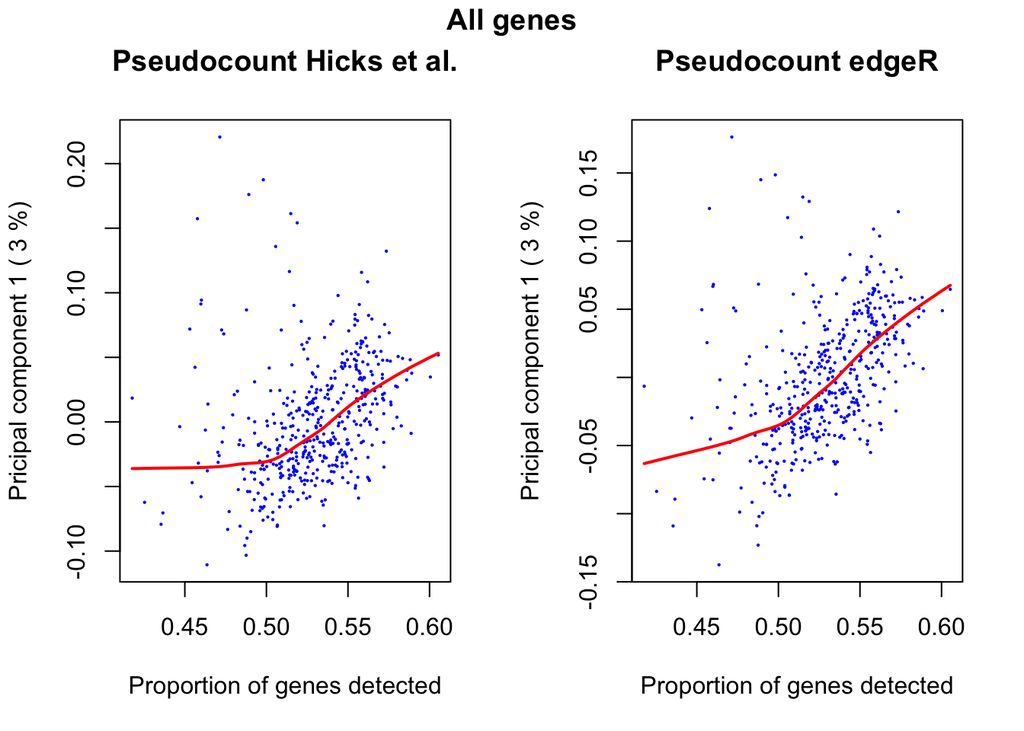

```r
par(mfrow = c(1,2))
pc_proportions_svd <- (svd_leng_scale$d^2)/sum(svd_leng_scale$d^2)
plot(x = detect_leng[which_detect_include],
     y = -1*svd_leng_scale$u[, 1],
     xlab = "Proportion of genes detected",
     ylab = paste("Pricipal component 1 (",
                  100*round(pc_proportions_svd[1], 2),"%)"),
     pch = 16, cex = .3, col = "blue",
     main = "Pseudocount Hicks et al.")
lines(lowess(x = detect_leng[which_detect_include],
            y = -1*svd_leng_scale$u[, 1]),
      col = "red", lwd = 2)

pc_proportions_svd_edger <- (svd_leng_edger_scale$d^2)/sum(svd_leng_edger_scale$d^2)
plot(x = detect_leng[which_detect_include],
     y = -1*svd_leng_edger_scale$u[, 1],
     xlab = "Proportion of genes detected",
     ylab = paste("Pricipal component 1 (",
                  100*round(pc_proportions_svd_edger[1], 2),"%)"),
     pch = 16, cex = .3, col = "blue",
     main = "Pseudocount edgeR")
lines(lowess(x = detect_leng[which_detect_include],
            y = -1*svd_leng_edger_scale$u[, 1]),
      col = "red", lwd = 2)

title(main = "All genes", outer = TRUE, line = -1)
```